# Trabalho 1: Regressão Logística - Proporção de Baixa Renda (RS)

CE314 - Modelos Lineares Generalizados (Grupo 4)

jonathas Pereira,……

# 1 Variáveis Pré-Selecionadas

| Variável | Descrição |
| --- | --- |
| `PropBaixaRenda` | Variável resposta binária (0 ou 1), derivada da “Proporção de pessoas com renda menor de ¼ do salário mínimo”. |
| `TxAnalfa` | Taxa de analfabetismo do município (%) |
| `TxDesemp` | Taxa de desemprego do município (%) |
| `PopRes` | População residente do município (Contagem) |
| `Saneat` | Quantidade de moradores com abastecimento de água (Contagem) |
| `ObtOcorr` | Óbitos ocorridos no município |

# 2 Preparação dos Dados

## 2.1 Leitura

```r
url <- "https://gist.githubusercontent.com/jonhsp/5cf24aa66c3fb173fea117bf4cb1dbc7/raw/29b6a4bcb197ab9be16663f8c73edcfd6b3c51f3/MunicipiosRS.xlsx%2520-%2520Quartis_1_e_3.csv"
df <- read_csv(url)
```

```r
df %<>%
  select(-'Prop<025SM') %>%
  # Isolando o nome do municipio (remove codigo e espaco inicial)
  mutate(MUNICIPIO = str_remove(MUNICIPIO, "^\\d+\\s")) %>%
  mutate(MUNICIPIO = str_to_lower(MUNICIPIO)) %>%
  # Tratando hifen como zero e convertendo para numerico
  mutate(across(
    .cols = c(TxAnalfa, TxDesemp, PopRes, ObtOcorr, Saneat),
    .fns = ~ {
      .x %>%
        str_replace("^-$", "0") %>%
        str_replace_all("\\.", "") %>%
        str_replace_all(",", ".") %>%
        as.numeric()
    }
  )) %>%
  # Criando a variável binária como fator
  mutate(y_bin = factor(PropBaixaRenda,
                        levels = c(0, 1),
                        labels = c("Baixa Proporção", "Alta Proporção"))) %>%
  # Renomeando as colunas para minúsculo
  rename_all(str_to_lower) %>%
  # Selecionando variaveis
  select(municipio, y_bin, txanalfa, txdesemp, popres, obtocorr, saneat)

summary(df)
```

```
##   municipio                     y_bin        txanalfa         txdesemp
##  Length:249         Baixa Proporção:124   Min.   : 0.900   Min.   : 0.0000
##  Class :character   Alta Proporção :125   1st Qu.: 3.200   1st Qu.: 0.8525
##  Mode  :character                         Median : 5.850   Median : 1.7150
##                                           Mean   : 6.645   Mean   : 2.1223
##                                           3rd Qu.: 9.700   3rd Qu.: 2.9000
##                                           Max.   :19.100   Max.   :10.9800
##                                           NA's   :1        NA's   :1
##      popres          obtocorr           saneat
##  Min.   :     0   Min.   :   0.00   Min.   :     0
##  1st Qu.:  2669   1st Qu.:   6.00   1st Qu.:  2656
##  Median :  4171   Median :  13.00   Median :  4162
##  Mean   : 10238   Mean   :  56.28   Mean   : 10183
##  3rd Qu.:  8771   3rd Qu.:  49.00   3rd Qu.:  8747
##  Max.   :435564   Max.   :2889.00   Max.   :433266
##
```

# 3 Distribuição das Variáveis

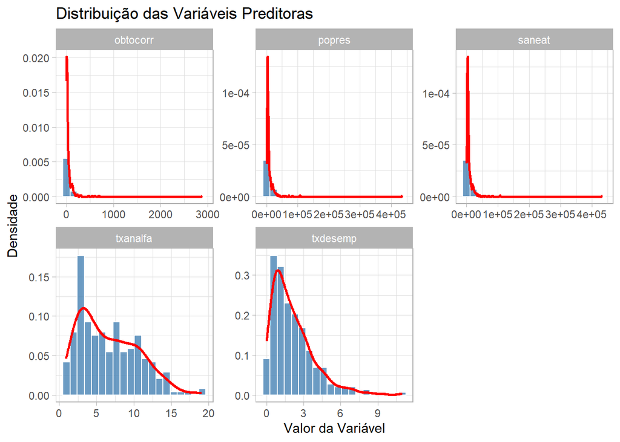

```r
df %>%
  # Seleciona apenas colunas numéricas
  select(where(is.numeric)) %>%
  # Pivota os dados para o formato longo (ideal para facet_wrap)
  pivot_longer(cols = everything(), names_to = "Variavel", values_to = "Valor") %>%

  ggplot(aes(x = Valor)) +
  geom_histogram(aes(y = ..density..), bins = 20, fill = "steelblue", color = "white", alpha = 0.8) +
  geom_density(color = "red", size = 1) +
  # Cria um mini-gráfico para cada variável
  facet_wrap(~ Variavel, scales = "free") +
  labs(
    title = "Distribuição das Variáveis Preditoras",
    x = "Valor da Variável",
    y = "Densidade"
  ) +
  theme_light()
```

# 4 Transformações

```r
df_transf <- df %>%
        # Remove municípios com população zero (evita log(0) = -Inf)
        filter(popres > 0) %>%
        # Remoção de NAs
        drop_na() %>%
        # log populacao
        mutate(log_popres = log(popres)) %>%
        # Obtos por 100.000 habitantes
        mutate(obt_100k = obtocorr / popres * 100000) %>%
        # Saneamento por 100.000 habitantes
        mutate(saneat_100k = saneat / popres * 100000) %>%
        # Remoção das variáveis originais
        select(-c(popres, obtocorr, saneat))
```

# 5 Distribuição das Variáveis Transformadas

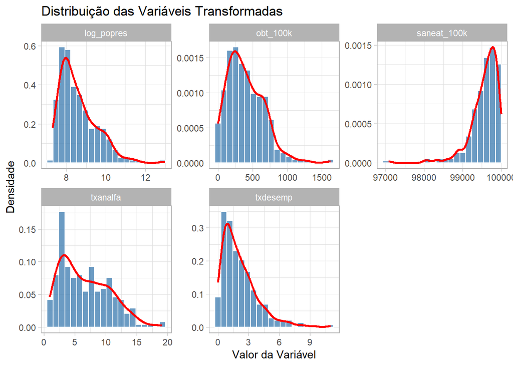

```r
df_transf %>%
  # Seleciona apenas colunas numéricas
  select(where(is.numeric)) %>%
  # Pivota os dados para o formato longo (ideal para facet_wrap)
  pivot_longer(cols = everything(), names_to = "Variavel", values_to = "Valor") %>%

  ggplot(aes(x = Valor)) +
  geom_histogram(aes(y = ..density..), bins = 20, fill = "steelblue", color = "white", alpha = 0.8) +
  geom_density(color = "red", size = 1) +
  # Cria um mini-gráfico para cada variável
  facet_wrap(~ Variavel, scales = "free") +
  labs(
    title = "Distribuição das Variáveis Transformadas",
    x = "Valor da Variável",
    y = "Densidade"
  ) +
  theme_light()
```

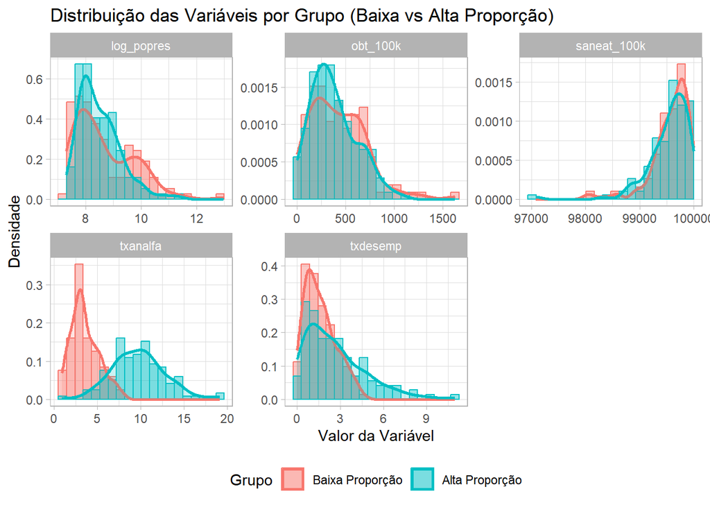

```r
# Visualização das variáveis numéricas por nível da variável resposta

df_transf %>%
  # 1. Seleciona numéricas E a variável resposta (y_bin)
  select(y_bin, where(is.numeric)) %>%

  # 2. Pivota apenas as numéricas, mantendo o y_bin fixo (cols = -y_bin)
  pivot_longer(cols = -y_bin, names_to = "Variavel", values_to = "Valor") %>%

  # 3. Adiciona 'fill = y_bin' para separar as cores por grupo
  ggplot(aes(x = Valor, fill = y_bin, color = y_bin)) +

  # position = "identity" permite que os histogramas se sobreponham (transparencia ajuda)
  geom_histogram(aes(y = ..density..), bins = 20, alpha = 0.4, position = "identity") +

  # Linha de densidade também separada por cor
  geom_density(alpha = 0.2, size = 1) +

  facet_wrap(~ Variavel, scales = "free") +

  labs(
    title = "Distribuição das Variáveis por Grupo (Baixa vs Alta Proporção)",
    x = "Valor da Variável",
    y = "Densidade",
    fill = "Grupo",
    color = "Grupo"
  ) +
  theme_light() +
  # Move a legenda para baixo para dar mais espaço aos gráficos
  theme(legend.position = "bottom")
```

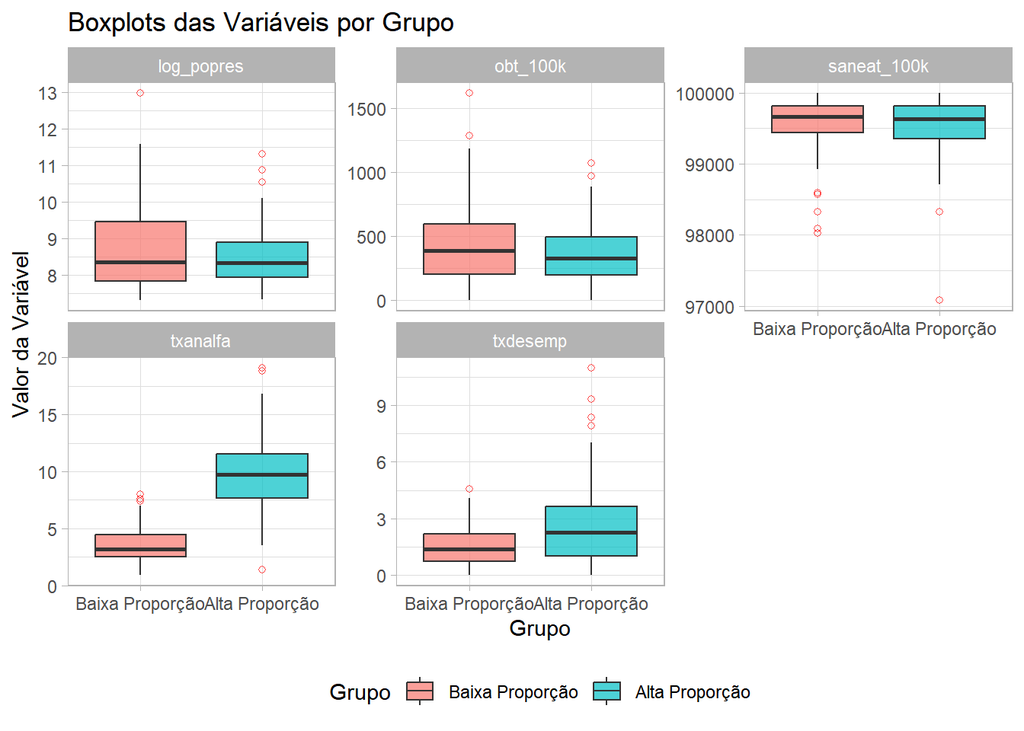

```r
# Visualização das variáveis numéricas por nível da variável resposta (Boxplot)

df_transf %>%
  # 1. Seleciona numéricas E a variável resposta (y_bin)
  select(y_bin, where(is.numeric)) %>%

  # 2. Pivota apenas as numéricas, mantendo o y_bin fixo
  pivot_longer(cols = -y_bin, names_to = "Variavel", values_to = "Valor") %>%

  # 3. MUDANÇA: Eixo X é o Grupo (y_bin), Eixo Y é o Valor numérico
  ggplot(aes(x = y_bin, y = Valor, fill = y_bin)) +

  # Geometria de Boxplot
  geom_boxplot(alpha = 0.7, outlier.colour = "red", outlier.shape = 1) +

  # Escalas livres no eixo Y para acomodar magnitudes diferentes
  facet_wrap(~ Variavel, scales = "free_y") +

  labs(
    title = "Boxplots das Variáveis por Grupo",
    x = "Grupo",
    y = "Valor da Variável",
    fill = "Grupo"
  ) +
  theme_light() +
  theme(legend.position = "bottom")
```

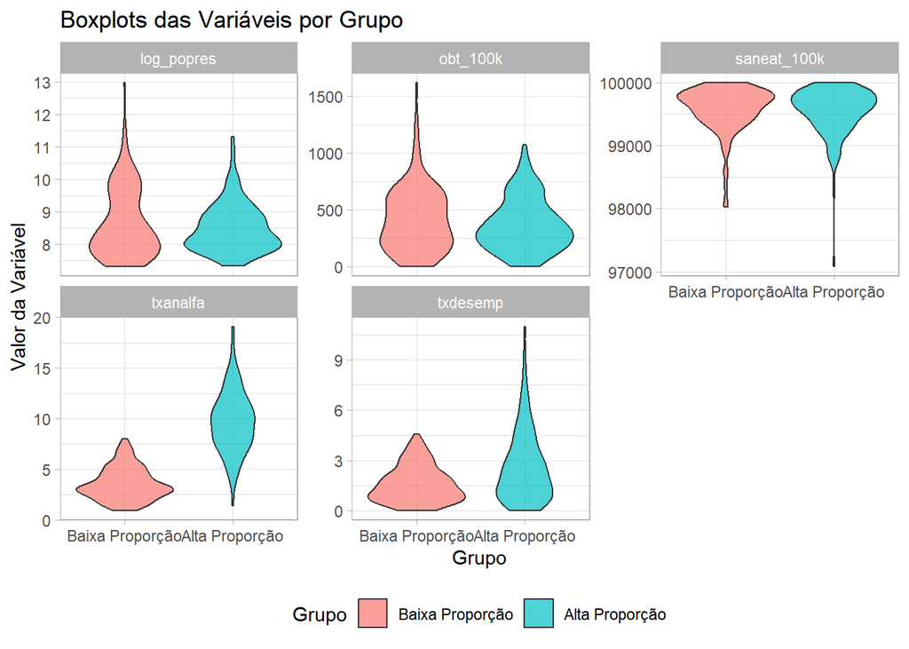

```r
# Visualização das variáveis numéricas por nível da variável resposta (Boxplot)

df_transf %>%
  # 1. Seleciona numéricas E a variável resposta (y_bin)
  select(y_bin, where(is.numeric)) %>%

  # 2. Pivota apenas as numéricas, mantendo o y_bin fixo
  pivot_longer(cols = -y_bin, names_to = "Variavel", values_to = "Valor") %>%

  # 3. MUDANÇA: Eixo X é o Grupo (y_bin), Eixo Y é o Valor numérico
  ggplot(aes(x = y_bin, y = Valor, fill = y_bin)) +

  # Geometria de Boxplot
  geom_violin(alpha = 0.7, outlier.colour = "red", outlier.shape = 1) +

  # Escalas livres no eixo Y para acomodar magnitudes diferentes
  facet_wrap(~ Variavel, scales = "free_y") +

  labs(
    title = "Boxplots das Variáveis por Grupo",
    x = "Grupo",
    y = "Valor da Variável",
    fill = "Grupo"
  ) +
  theme_light() +
  theme(legend.position = "bottom")
```

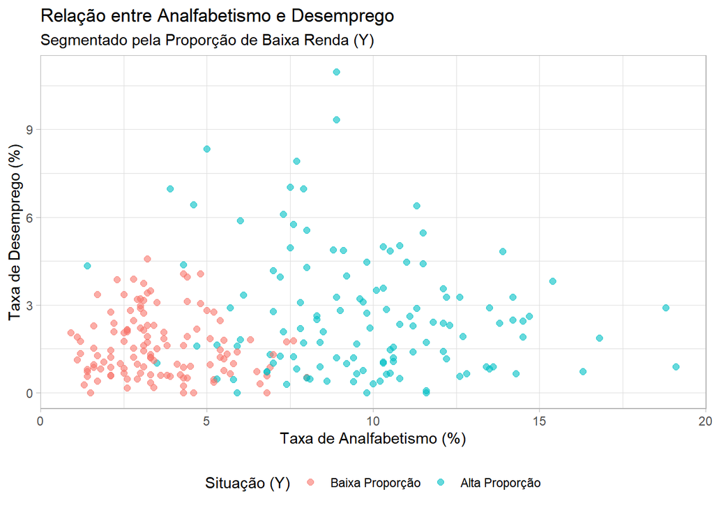

```r
# Gráfico de Dispersão: Analfabetismo vs Desemprego por Grupo

df_transf %>%
  ggplot(aes(x = txanalfa, y = txdesemp, color = y_bin)) +

  # Adiciona os pontos (dispersão)
  geom_point(alpha = 0.6, size = 2) +

  labs(
    title = "Relação entre Analfabetismo e Desemprego",
    subtitle = "Segmentado pela Proporção de Baixa Renda (Y)",
    x = "Taxa de Analfabetismo (%)",
    y = "Taxa de Desemprego (%)",
    color = "Situação (Y)"
  ) +

  theme_light() +
  theme(legend.position = "bottom")
```

# 6 4. Ajustes de Modelos

Estamos construindo os modelos progressivamente. O objetivo é encontrar o equilíbrio entre simplicidade e capacidade explicativa.

## 6.1 Modelo 1 - Todas as variáveis (Linear)

Este é o modelo base (saturado), assumindo que todas as relações são lineares.

```r
# Ajuste do modelo apenas com efeitos principais lineares
ajuste_1 <- glm(y_bin ~ txanalfa + txdesemp + log_popres + saneat_100k + obt_100k,
                data = df_transf,
                family = binomial(link = "logit"))

# Sumário para ver coeficientes e significância individual
summary(ajuste_1)
```

```
##
## Call:
## glm(formula = y_bin ~ txanalfa + txdesemp + log_popres + saneat_100k +
##     obt_100k, family = binomial(link = "logit"), data = df_transf)
##
## Coefficients:
##               Estimate Std. Error z value Pr(>|z|)
## (Intercept)  4.213e+01  1.019e+02   0.413   0.6792
## txanalfa     1.309e+00  2.008e-01   6.517 7.16e-11 ***
## txdesemp     7.262e-01  2.438e-01   2.979   0.0029 **
## log_popres   3.227e-01  4.258e-01   0.758   0.4485
## saneat_100k -5.364e-04  1.015e-03  -0.528   0.5973
## obt_100k    -1.951e-03  1.231e-03  -1.585   0.1129
## ---
## Signif. codes:  0 '***' 0.001 '**' 0.01 '*' 0.05 '.' 0.1 ' ' 1
##
## (Dispersion parameter for binomial family taken to be 1)
##
##     Null deviance: 343.80  on 247  degrees of freedom
## Residual deviance:  89.62  on 242  degrees of freedom
## AIC: 101.62
##
## Number of Fisher Scoring iterations: 7
```

```r
# Análise de Deviance (ANOVA) para ver a contribuição de cada variável ao ser adicionada
# O teste "Chisq" é o adequado para GLMs binomiais
anova(ajuste_1, test = "Chisq")
```

```
## Analysis of Deviance Table
##
## Model: binomial, link: logit
##
## Response: y_bin
##
## Terms added sequentially (first to last)
##
##
##             Df Deviance Resid. Df Resid. Dev  Pr(>Chi)
## NULL                          247     343.80
## txanalfa     1  230.449       246     113.35 < 2.2e-16 ***
## txdesemp     1   20.541       245      92.81 5.838e-06 ***
## log_popres   1    0.037       244      92.77   0.84706
## saneat_100k  1    0.140       243      92.63   0.70779
## obt_100k     1    3.014       242      89.62   0.08257 .
## ---
## Signif. codes:  0 '***' 0.001 '**' 0.01 '*' 0.05 '.' 0.1 ' ' 1
```

### 6.1.1 Diagnóstico do Modelo 1 (Efeitos Lineares)

A análise do modelo inicial (apenas efeitos principais lineares) revela os seguintes pontos:

1. **Qualidade do Ajuste:**
   - **AIC:** 101.62 (Base de comparação).
   - **Deviance Residual:** Reduziu de 343.80 (Nulo) para 89.62, indicando que o conjunto de variáveis explica uma grande parcela da variabilidade dos dados.
2. **Significância dos Preditores:**
   - **`txanalfa` (Analfabetismo):** Altamente significativa ($p < 0.001$). O coeficiente positivo ($1.31$) confirma que quanto maior o analfabetismo, maior a chance de o município pertencer ao grupo de alta pobreza.
   - **`txdesemp` (Desemprego):** Significativa ($p = 0.003$). Coeficiente positivo ($0.73$), indicando que o desemprego também impulsiona a pobreza.
   - **`log_popres` (População):** Não significativa ($p = 0.45$). Isso sugere que, em uma relação puramente linear, o tamanho do município não distingue bem os grupos de renda. Isso reforça a necessidade de testar termos quadráticos.
   - **`saneat_100k` e `obt_100k`:** Não apresentaram significância estatística neste modelo ($p > 0.05$).

**Conclusão:** O modelo captura bem os efeitos de educação e trabalho, mas falha em capturar a influência da demografia (população) e infraestrutura (saneamento) em sua forma linear.

## 6.2 Modelo 2 - Termos Quadráticos (Não-Linearidade)

Com base na análise exploratória, adicionamos termos quadráticos para **População** e **Desemprego**, mantendo as demais variáveis lineares. O objetivo é testar se a relação com a pobreza é curvilínea.

```r
# Ajuste do modelo com polinômios de 2º grau para as variáveis identificadas
ajuste_2 <- glm(y_bin ~ txanalfa + saneat_100k + obt_100k +
                poly(txdesemp, 2) +
                poly(log_popres, 2),
                data = df_transf,
                family = binomial(link = "logit"))

# Sumário para verificar a significância dos termos quadráticos
summary(ajuste_2)
```

```
##
## Call:
## glm(formula = y_bin ~ txanalfa + saneat_100k + obt_100k + poly(txdesemp,
##     2) + poly(log_popres, 2), family = binomial(link = "logit"),
##     data = df_transf)
##
## Coefficients:
##                        Estimate Std. Error z value Pr(>|z|)
## (Intercept)           2.809e+01  1.023e+02   0.275  0.78369
## txanalfa              1.332e+00  2.108e-01   6.321  2.6e-10 ***
## saneat_100k          -3.436e-04  1.028e-03  -0.334  0.73817
## obt_100k             -3.396e-03  1.667e-03  -2.037  0.04170 *
## poly(txdesemp, 2)1    4.882e+01  1.689e+01   2.891  0.00384 **
## poly(txdesemp, 2)2    3.683e+01  1.667e+01   2.209  0.02716 *
## poly(log_popres, 2)1  1.091e+00  8.316e+00   0.131  0.89559
## poly(log_popres, 2)2 -2.059e+01  9.309e+00  -2.211  0.02700 *
## ---
## Signif. codes:  0 '***' 0.001 '**' 0.01 '*' 0.05 '.' 0.1 ' ' 1
##
## (Dispersion parameter for binomial family taken to be 1)
##
##     Null deviance: 343.801  on 247  degrees of freedom
## Residual deviance:  80.534  on 240  degrees of freedom
## AIC: 96.534
##
## Number of Fisher Scoring iterations: 8
```

```r
# Teste de Deviance (ANOVA) para comparar se o Modelo 2 é superior ao Modelo 1
# H0: Os modelos são iguais (a complexidade extra não ajuda)
# H1: O Modelo 2 é melhor
anova(ajuste_1, ajuste_2, test = "Chisq")
```

```
## Analysis of Deviance Table
##
## Model 1: y_bin ~ txanalfa + txdesemp + log_popres + saneat_100k + obt_100k
## Model 2: y_bin ~ txanalfa + saneat_100k + obt_100k + poly(txdesemp, 2) +
##     poly(log_popres, 2)
##   Resid. Df Resid. Dev Df Deviance Pr(>Chi)
## 1       242     89.620
## 2       240     80.534  2   9.0862  0.01064 *
## ---
## Signif. codes:  0 '***' 0.001 '**' 0.01 '*' 0.05 '.' 0.1 ' ' 1
```

### 6.2.1 Diagnóstico do Modelo 2 (Termos Quadráticos)

Os resultados obtidos a partir do ajuste do modelo com termos quadráticos indicam uma superioridade clara sobre o modelo linear simples (Modelo 1). A análise detalhada segue abaixo:

1. **Teste de Razão de Verossimilhança (ANOVA):** A comparação formal entre os modelos resultou em um **p-valor de 0.0106** (Chi-quadrado). Como $p < 0.05$, rejeitamos a hipótese nula de que os modelos são equivalentes. Isso prova estatisticamente que a inclusão da curvatura para Desemprego e População adicionou poder explicativo real ao modelo, e não apenas ruído.
2. **Critério de Akaike (AIC):** O AIC reduziu de **101.62** (Modelo 1) para **96.53** (Modelo 2). Uma queda dessa magnitude confirma que o Modelo 2 é mais eficiente: ele explica melhor os dados mesmo sendo penalizado pela complexidade adicional dos termos quadráticos.
3. **Análise dos Coeficientes:**
   - **Não-Linearidade Confirmada:** Os termos quadráticos para Desemprego (`poly(txdesemp, 2)2`, p=0.027) e População (`poly(log_popres, 2)2`, p=0.027) foram estatisticamente significativos. Isso sugere que a relação dessas variáveis com a pobreza não é constante, variando conforme a magnitude dos indicadores (formato de curva).
   - **Preditores Fortes:** A Taxa de Analfabetismo (`txanalfa`) permanece como o preditor mais robusto do modelo ($p < 0.001$), mantendo seu efeito positivo forte.
   - **Variáveis Redundantes:** A variável de Saneamento (`saneat_100k`) apresentou p-valor alto (0.73), sugerindo que, na presença das outras variáveis (especialmente Analfabetismo), ela não adiciona informação nova relevante para a classificação.
   - **Óbitos:** Curiosamente, a taxa de óbitos (`obt_100k`) tornou-se significativa ($p=0.04$) neste modelo ajustado.

**Conclusão:** O Modelo 2 será adotado como base para a seleção final. O próximo passo será refinar este modelo aplicando o método *Stepwise* para remover automaticamente os preditores não significativos (como o Saneamento) e obter o modelo final parcimonioso.

# 7 5. Seleção do Modelo Final e Diagnóstico

Nesta etapa, refinamos o modelo quadrático removendo variáveis redundantes pelo critério de Akaike (AIC) e realizamos os diagnósticos de qualidade do ajuste.

## 7.1 5.1 Seleção de Variáveis (Stepwise)

Utilizamos o método *stepwise* (direção “both”) para remover preditores não significativos e chegar ao modelo mais parcimonioso possível.

```r
# Aplica o algoritmo Stepwise no Modelo 2 (Quadrático)
# O R testará remover/adicionar variáveis para baixar o AIC
modelo_final <- step(ajuste_2, direction = "both", trace = 1)
```

```
## Start:  AIC=96.53
## y_bin ~ txanalfa + saneat_100k + obt_100k + poly(txdesemp, 2) +
##     poly(log_popres, 2)
```

```
##                       Df Deviance     AIC
## - saneat_100k          1   80.645  94.645
## <none>                     80.534  96.534
## - poly(log_popres, 2)  2   86.426  98.426
## - obt_100k             1   86.482 100.482
## - poly(txdesemp, 2)    2  101.088 113.088
## - txanalfa             1  276.631 290.631
```

```
##
## Step:  AIC=94.65
## y_bin ~ txanalfa + obt_100k + poly(txdesemp, 2) + poly(log_popres,
##     2)
```

```
##                       Df Deviance     AIC
## <none>                     80.645  94.645
## + saneat_100k          1   80.534  96.534
## - poly(log_popres, 2)  2   86.943  96.943
## - obt_100k             1   86.579  98.579
## - poly(txdesemp, 2)    2  101.596 111.596
## - txanalfa             1  277.305 289.305
```

```r
# Exibe o resumo do modelo vencedor
summary(modelo_final)
```

```
##
## Call:
## glm(formula = y_bin ~ txanalfa + obt_100k + poly(txdesemp, 2) +
##     poly(log_popres, 2), family = binomial(link = "logit"), data = df_transf)
##
## Coefficients:
##                        Estimate Std. Error z value Pr(>|z|)
## (Intercept)           -6.124315   1.168673  -5.240 1.60e-07 ***
## txanalfa               1.334196   0.210857   6.327 2.49e-10 ***
## obt_100k              -0.003382   0.001666  -2.030  0.04237 *
## poly(txdesemp, 2)1    49.542674  16.900795   2.931  0.00337 **
## poly(txdesemp, 2)2    37.308868  16.737594   2.229  0.02581 *
## poly(log_popres, 2)1   1.500561   8.255232   0.182  0.85576
## poly(log_popres, 2)2 -20.826304   9.307757  -2.238  0.02525 *
## ---
## Signif. codes:  0 '***' 0.001 '**' 0.01 '*' 0.05 '.' 0.1 ' ' 1
##
## (Dispersion parameter for binomial family taken to be 1)
##
##     Null deviance: 343.801  on 247  degrees of freedom
## Residual deviance:  80.645  on 241  degrees of freedom
## AIC: 94.645
##
## Number of Fisher Scoring iterations: 8
```

# 8 5.3 Interpretação dos Efeitos (Odds Ratios)

A tabela abaixo apresenta a Razão de Chances (Odds Ratios) para as variáveis do modelo final.

```r
# Extração dos coeficientes e cálculo do OR (exp(beta))
tabela_or <- exp(cbind(OR = coef(modelo_final), confint(modelo_final)))

# Exibição formatada
knitr::kable(tabela_or, digits = 3, caption = "Razão de Chances (Odds Ratios) e IC 95%")
```

Razão de Chances (Odds Ratios) e IC 95%

|  | OR | 2.5 % | 97.5 % |
| --- | --- | --- | --- |
| (Intercept) | 2.000000e-03 | 0.000000e+00 | 1.700000e-02 |
| txanalfa | 3.797000e+00 | 2.656000e+00 | 6.134000e+00 |
| obt_100k | 9.970000e-01 | 9.930000e-01 | 9.990000e-01 |
| poly(txdesemp, 2)1 | 3.281785e+21 | 4.870959e+09 | 3.217645e+37 |
| poly(txdesemp, 2)2 | 1.596009e+16 | 2.471136e+04 | 1.100227e+32 |
| poly(log_popres, 2)1 | 4.484000e+00 | 0.000000e+00 | 8.329645e+07 |
| poly(log_popres, 2)2 | 0.000000e+00 | 0.000000e+00 | 7.000000e-02 |

### 8.0.1 Interpretação dos Coeficientes do Modelo Final

A tabela de coeficientes do modelo selecionado (`modelo_final`) revela as seguintes relações estatísticas com a probabilidade de um município apresentar alta proporção de baixa renda:

**1. Taxa de Analfabetismo (`txanalfa`)** * **Estimativa:** $1.33$ * **Significância:** $p < 0.001$ (*)* Interpretação:** É o preditor mais forte e consistente do modelo. O coeficiente positivo indica uma relação direta: quanto maior a taxa de analfabetismo, **maior** a probabilidade do município pertencer ao grupo de alta pobreza.

**2. Taxa de Desemprego (`poly(txdesemp, 2)`)** * **Termo Linear:** $49.54$ ($p = 0.003$ **) *** Termo Quadrático:** $37.31$ ($p = 0.026$ *)* **Interpretação:** A significância de ambos os termos confirma que a relação entre desemprego e pobreza **não é linear**. O fato de ambos os coeficientes serem positivos sugere um efeito acelerado: o impacto do desemprego na pobreza torna-se mais severo à medida que as taxas de desemprego aumentam.

**3. Tamanho da População (`poly(log_popres, 2)`)** * **Termo Linear:** $1.50$ ($p = 0.856$, não significativo) * **Termo Quadrático:** $-20.83$ ($p = 0.025$ *)* **Interpretação:** Apenas o termo quadrático é significativo e possui sinal negativo. Isso indica uma relação curvilínea (formato de “U invertido” no espaço das chances). Isso sugere que a dinâmica da pobreza varia conforme a escala do município, comportando-se de maneira diferente em municípios de porte médio comparado aos extremos (muito pequenos ou muito grandes).

### 8.0.2 Qualidade do Ajuste

- **Redução da Deviance:** O modelo reduziu a Deviance Nula de **343.80** para uma Deviance Residual de **80.64**, indicando que os preditores selecionados explicam uma parcela substancial da variabilidade dos dados.
- **AIC:** O valor final de **94.65** representa o melhor compromisso encontrado entre ajuste e complexidade.